# Functional Analysis of Heart Rate Dynamics

Jenna Lu

2026-07-27

# Overview

Physiological responses are dynamic processes that evolve over time rather than static measurements.

This notebook explores heart rate trajectories as functional data and investigates how cardiac responses vary across experimental conditions in the WESAD dataset.

# Libraries

```r
library(tidyverse)
library(here)
library(fda)
```

# Load Heart Rate Data

```r
hr_data <- read_csv(
  here(
    "data",
    "processed",
    "S2_heart_rate.csv"
  )
)
glimpse(hr_data)
```

```
## Rows: 5,921
## Columns: 2
## $ time       <dbl> 0.9985714, 1.7242857, 2.4914286, 3.3971429, 4.2885714, 5.19…
## $ heart_rate <dbl> 77.63401, 82.67717, 78.21229, 66.24606, 67.30769, 66.14173,…
```

# Load Condition Labels

The original ECG data contains experimental condition labels.

```r
ecg_data <- read_csv(
  here(
    "data",
    "processed",
    "S2_ecg_filtered.csv"
  )
)
condition_data <- ecg_data %>%
  dplyr::select(
    time,
    label
  )
```

# Match Heart Rate to Conditions

Heart rate is measured at detected beat locations, while labels are sampled at the ECG frequency.

```r
hr_condition <- hr_data %>%
  mutate(
    label = condition_data$label[
      match(
        round(time, 3),
        round(condition_data$time, 3)
      )
    ]
  )


head(hr_condition)
```

```
## # A tibble: 6 × 3
##    time heart_rate label
##   <dbl>      <dbl> <dbl>
## 1 0.999       77.6     0
## 2 1.72        82.7     0
## 3 2.49        78.2     0
## 4 3.40        66.2     0
## 5 4.29        67.3     0
## 6 5.20        66.1     0
```

# Condition Summary

```r
hr_condition %>%
  dplyr::group_by(label) %>%
  dplyr::summarise(
    mean_hr = mean(heart_rate, na.rm=TRUE),
    sd_hr = sd(heart_rate, na.rm=TRUE),
    n=dplyr::n()
  )
```

```
## # A tibble: 7 × 4
##   label mean_hr sd_hr     n
##   <dbl>   <dbl> <dbl> <int>
## 1     0    66.6 14.5   2872
## 2     1    68.6 10.7   1227
## 3     2    72.8 11.9    673
## 4     3    59.3 15.3    313
## 5     4    62.5 13.2    702
## 6     6    72.6 10.2     70
## 7     7    69.9  9.65    64
```

# Visualize Heart Rate Trajectory

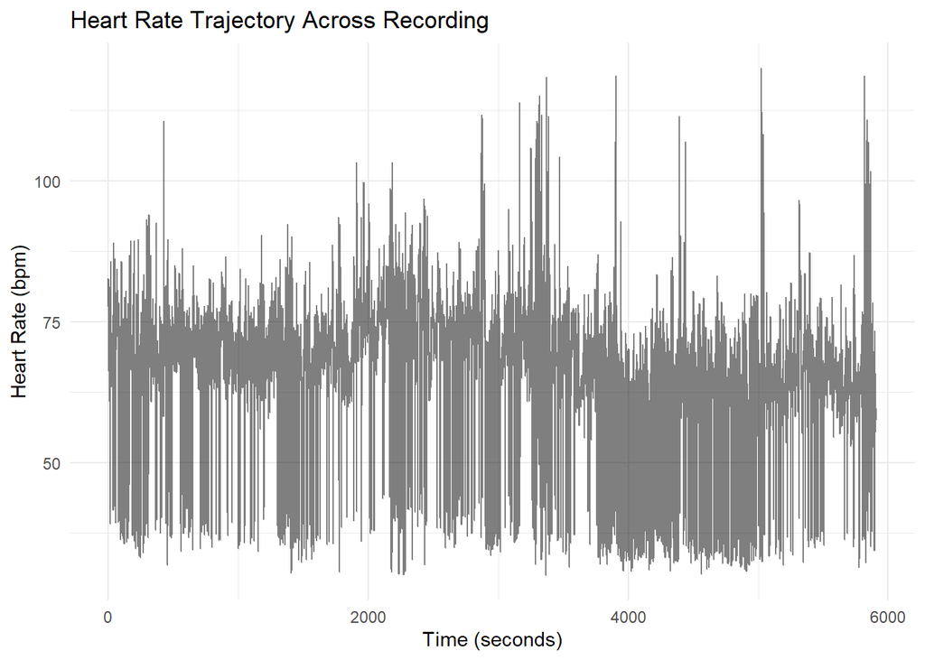

```r
ggplot(
  hr_condition,
  aes(
    x=time,
    y=heart_rate
  )
) +
  geom_line(alpha=0.5) +
  labs(
    title="Heart Rate Trajectory Across Recording",
    x="Time (seconds)",
    y="Heart Rate (bpm)"
  ) +
  theme_minimal()
```

# Smooth Heart Rate Function

Physiological signals contain short-term variability. Functional data analysis represents the underlying trajectory using smooth basis functions.

```r
time_grid <- hr_condition$time

basis <- create.bspline.basis(
  rangeval = range(time_grid),
  nbasis = 25
)


hr_fd <- Data2fd(
  argvals = time_grid,
  y = hr_condition$heart_rate,
  basisobj = basis
)


hr_fd
```

```
## $coefs
##              [,1]
## bspl4.1  76.50972
## bspl4.2  56.55375
## bspl4.3  69.77343
## bspl4.4  68.87354
## bspl4.5  68.83986
## bspl4.6  69.81300
## bspl4.7  66.22657
## bspl4.8  64.22867
## bspl4.9  74.22961
## bspl4.10 75.97976
## bspl4.11 70.52360
## bspl4.12 75.50806
## bspl4.13 63.17745
```

[output cut: 490 more lines]

# Plot Functional Representation

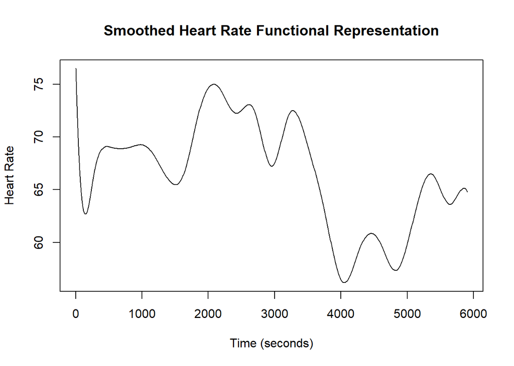

[output not shown]

```r
plot(
  hr_fd,
  main="Smoothed Heart Rate Functional Representation",
  xlab="Time (seconds)",
  ylab="Heart Rate"
)
```

# Functional Derivative

The first derivative describes the rate of change of heart rate over time.

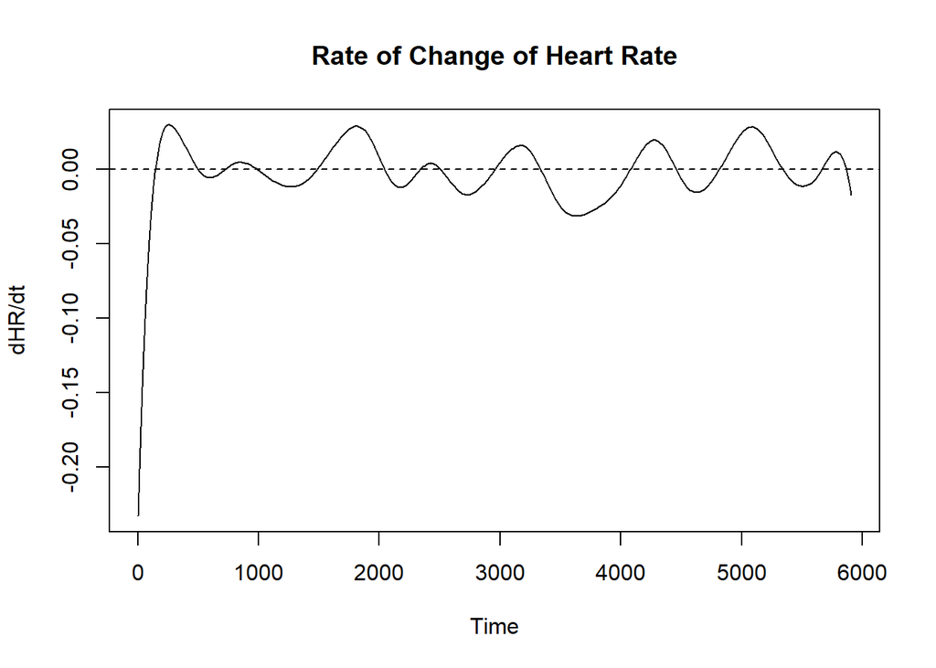

[output not shown]

```r
hr_velocity <- fda::deriv.fd(
  hr_fd,
  Lfdobj = 1
)

plot(
  hr_velocity,
  main="Rate of Change of Heart Rate",
  xlab="Time",
  ylab="dHR/dt"
)
```

# Summary

This notebook represents physiological signals as continuous functions rather than isolated measurements.

Functional representations allow future modeling of:

- stress-response trajectories
- individual variability
- longitudinal physiological patterns
- condition-specific cardiac dynamics